# Pseudotime Analysis

Install packages

```r
library(Seurat)
library(slingshot)
library(ggplot2)
library(RColorBrewer)
library(scater)
```

Load the seurat object

```r
sc.seurat <- readRDS("../data/seurat.rds")
```

Load highly variable features

```r
varfeat <- read.table('../data/highly_variable_features.tsv', stringsAsFactors=F)
colnames(varfeat) <- "vfs"
varfeat$vfs <- apply(matrix(varfeat$vfs), 1, substring, first=17)
```

Scale data

```r
sc.seurat <- ScaleData(sc.seurat)
```

Run PCA, using the variable features determined in scanpy

```r
sc.seurat <- RunPCA(sc.seurat, features=varfeat$vfs)
```

```
PC_ 1
Positive:  APOBEC3G, FGF17, RHOBTB3, CER1, CYP26A1, SERHL2, LHX1, CFLAR, COL5A2, CCDC81
       FREM1, NFKBIA, TRMT44, ACOX3, VIM, GYPB, ARL4D, C1orf61, MYL7, ENC1
       ZNF571, SLCO2A1, SOX17, CCKBR, CPE, NRP1, HAS2, ENPP7P8, ANGPT2, NPPB
Negative:  POLR3G, THY1, USP44, VASH2, PMEL, GPC3, RARRES2, CRABP1, OLFML3, MT1X
       CCND1, NEFM, B3GNT7, FGF19, POU5F1, SPP1, C9orf135, IDO1, RASGRP2, PTN
       ADM, NMU, HES3, TRIML2, CHGA, S100A4, FABP3, FOXB1, TNNI3, CALD1
PC_ 2
Positive:  MIXL1, T, DKK4, SP5, GAD1, DKK1, GSC, MESP1, APLNR, ID2
       POLB, SERPINB9, HES1, LYPD1, WLS, CER1, FST, FGF4, ID1, ENPP7P8
       EGR1, SERPINE2, BAMBI, COCH, MSX1, GADD45B, IFITM1, CDA, LHX1, B3GNT7
Negative:  TPM1, S100A16, PRKCDBP, ANXA3, ISG15, RAB17, IDO1, TRIML2, STC1, ADM
       RGS5, CHAC1, MYL9, CALD1, DBNDD2, ZMYND8, SORBS2, C9orf135, RASGRP2, LMCD1
       CCKBR, KRT19, CSRP1, SDC2, DDIT4, SPP1, CNN1, USP44, AFP, TAGLN
PC_ 3
Positive:  SHISA2, BNIP3, SOX17, FAM184A, TESC, BST2, LRIG1, FREM1, SLC5A9, DBNDD2
       LEFTY1, IGFBP2, VIPR2, CCL2, DIO3, CXCR4, LEFTY2, CCDC81, CCKBR, MGST2
       SEMA3E, IFI16, WDR86, KIT, TNNI3, RAB17, SLC40A1, ZMYND8, TRDN, FAM159B
Negative:  TAGLN, ANKRD1, WDPCP, WLS, PRSS35, CDH11, GADD45B, THBS1, NPPA, HEG1
       RGS5, NPPB, ACTC1, DKK1, CNN1, TAGLN2, CYR61, CTGF, HAPLN1, BAMBI
       GAD1, HES1, CALD1, TENM2, ANXA1, MYL9, LUM, PLAU, COBLL1, LYPD1
PC_ 4
Positive:  SP5, FRZB, T, GAD1, FAM184A, RPRM, ID2, GDF3, LEFTY1, FAM159B
       LEFTY2, DIO3, S100A10, IFITM1, MATN3, ANXA3, KRT8, PTGR1, SEMA3E, SLC40A1
       GATM, BAMBI, FGF8, GAL, KLF5, APOA1, GLIPR1L1, CCL2, S100A13, SOX17
Negative:  ANGPT2, SHISA2, DLL3, RIPPLY1, NRP2, PLAU, CUZD1, NRP1, PDLIM3, APLNR
       PDZRN4, PMP22, CD177, GYPA, IDO1, POLB, PIK3R5, FOXO1, CRABP2, GYPE
       LDB2, LHX1, RFPL2, ZAP70, LRIG1, FAM24B, ARL4D, RASGRP2, TRIML2, TENM2
PC_ 5
Positive:  CDH6, NOG, HAPLN1, IGFBP7, ACTA2, COL11A1, ANXA1, CDH11, SERPINE1, SNAI2
       HTRA1, LUM, PRSS23, COL1A1, FN1, GAN, PALLD, TMEM88, NPPA, GYPE
       ITGAV, B3GNT7, GYPA, TNFRSF11B, SORBS2, FRMD4B, ANKRD1, LGR5, IGF2, COL2A1
Negative:  HIST1H1C, HIST1H1D, HIST1H4C, HIST1H2AJ, HIST1H1E, HIST1H1B, HIST1H2AH, HIST1H3I, HIST1H2AM, HIST1H3D
       HIST1H3G, APOC1, HIST1H3F, GAL, HIST4H4, HIST1H1A, FAM159B, HIST1H2BH, CBR1, WFDC2
       NDUFA3, HIST1H2BC, HIST1H4H, HIST2H2AA4, POLB, HIST1H2AC, CDA, IFITM1, KRT19, IFITM3
```

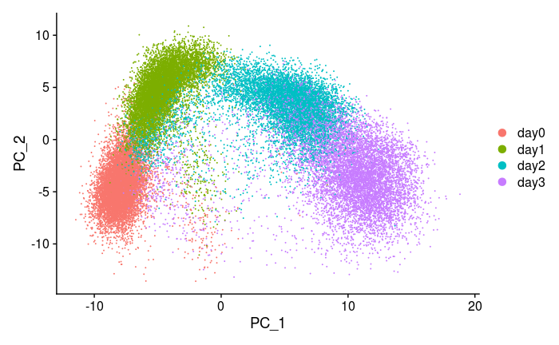

```r
PCAPlot(sc.seurat, group.by="day")
```

Looks like before, but note that PC2 has been reversed (PCA is sign invariant). From here, we can get our first pseudotime assignment (PC1, as used in the paper), and compare it to the component that Stegle found

```r
pseudotime <- data.frame(sc.seurat$pca@cell.embeddings[,colnames(sc.seurat$pca@cell.embeddings)=="PC_1"])
colnames(pseudotime) <- "PC1"
pseudotime$PC1 <- pseudotime$PC1 + abs(min(pseudotime$PC1))
pseudotime$PC1 <- pseudotime$PC1 / max(pseudotime$PC1)
pseudotime$"stegle" <- sc.seurat$pseudo
```

Now let’s compare this to the pseudotime that Stegle presented

```r
ggplot(data=pseudotime, aes(x=stegle, y=PC1)) +
  geom_point(size=0.1) +
  geom_line(aes(y=stegle), color='red')
```

[output not shown]

To move onto the next pseudotime assignment, we can use Slingshot

```r
sc.slingshot <- RunPCA(sc.seurat, npcs=2, features=varfeat$vfs)
sc.slingshot <- as.SingleCellExperiment(sc.slingshot)
```

```r
sling <- slingshot(sc.slingshot, clusterLabels = "day", reducedDim="PCA")
```

```r
colors <- colorRampPalette(brewer.pal(11,'Spectral')[-6])(100)
plotcol <- colors[cut(sling$slingPseudotime_1, breaks=100)]
plot(reducedDims(sling)$PCA, col = plotcol, pch=16, asp = 1)
lines(SlingshotDataSet(sling), lwd=2, col='black')
```

[output not shown]

```r
pseudotime <- data.frame(sling$pseudo)
colnames(pseudotime) <- "stegle"
pseudotime$"slingshot" <- sling$slingPseudotime_1
pseudotime$"slingshot" <- 1 - pseudotime$"slingshot" / max(pseudotime$"slingshot")
ggplot(data=pseudotime, aes(x=stegle, y=slingshot)) +
  geom_point(size=0.1) +
  geom_line(aes(y=stegle), color='red')
```

[output not shown]

Let’s try calculating pseudotime from UMAP instead

```r
sc.seurat <- FindNeighbors(sc.seurat, dims=1:50)

sc.seurat <- RunUMAP(sc.seurat, dims=1:50, n.neighbors=5, min.dist=0.2)
DimPlot(sc.seurat, group.by="day")

sc.seurat <- RunUMAP(sc.seurat, dims=1:50, n.neighbors=25, min.dist=0.2)
DimPlot(sc.seurat, group.by="day")

sc.seurat <- RunUMAP(sc.seurat, dims=1:50, n.neighbors=50, min.dist=0.2)
DimPlot(sc.seurat, group.by="day")

sc.seurat <- RunUMAP(sc.seurat, dims=1:50, n.neighbors=5, min.dist=0.5)
DimPlot(sc.seurat, group.by="day")

sc.seurat <- RunUMAP(sc.seurat, dims=1:50, n.neighbors=25, min.dist=0.5)
DimPlot(sc.seurat, group.by="day")

sc.seurat <- RunUMAP(sc.seurat, dims=1:50, n.neighbors=50, min.dist=0.5)
DimPlot(sc.seurat, group.by="day")

sc.seurat <- RunUMAP(sc.seurat, dims=1:50, n.neighbors=5, min.dist=0.8)
DimPlot(sc.seurat, group.by="day")

sc.seurat <- RunUMAP(sc.seurat, dims=1:50, n.neighbors=25, min.dist=0.8)
DimPlot(sc.seurat, group.by="day")

sc.seurat <- RunUMAP(sc.seurat, dims=1:50, n.neighbors=50, min.dist=0.8)
DimPlot(sc.seurat, group.by="day")
```

[output not shown]

```r
sc.seurat <- RunUMAP(sc.seurat, dims=1:50, n.neighbors=50, min.dist=0.75)
DimPlot(sc.seurat, group.by="day")
```

[output not shown]

Let’s see what slingshot can do with this

```r
sc.sce.umap <- as.SingleCellExperiment(sc.seurat)
```

```r
sc.sce.umap <- slingshot(sc.sce.umap, clusterLabels='day', reducedDim="UMAP")
```

Compare UMAP pseudotime to stegle and add it to the dataframe

```r
pseudotime$"UMAP" <- sc.sce.umap$slingPseudotime_1
pseudotime$"UMAP" <- 1-pseudotime$"UMAP" / max(pseudotime$"UMAP")
ggplot(data=pseudotime, aes(x=stegle, y=UMAP)) +
  geom_point(size=0.1) +
  geom_line(aes(y=stegle), color='red')
```

[output not shown]

```r
sc.sce.umap <- getCurves(sc.sce.umap)
```

View UMAP-based principal curve

```r
cl1 <- unclass(as.factor(sc.sce.umap$day))
plot(reducedDims(sc.sce.umap)$UMAP, col = brewer.pal(4,"Spectral")[cl1], pch=16, cex=0.3, xlim=c(-12,12))
lines(SlingshotDataSet(sc.sce.umap), lwd=2, col='black')
legend(x=9.5, y=-5, legend=c("Day 0", "Day 1", "Day 2", "Day 3"),
       fill=brewer.pal(4,"Spectral"), cex=0.8)
```

[output not shown]

```r
cl1 <- unclass(as.factor(sc.sce.pca$day))
plot(reducedDims(sc.sce.pca)$PCA, col = brewer.pal(4,"Spectral")[cl1], pch=16, cex=0.3, xlim=c(-12,18))
lines(SlingshotDataSet(sc.sce.pca), lwd=2, col='black')
legend(x=13, y=-4, legend=c("Day 0", "Day 1", "Day 2", "Day 3"),
       fill=brewer.pal(4,"Spectral"), cex=0.8)
```

[output not shown]

Write pseudotimes to a metadata file

```r
sc.pseudo <- AddMetaData(sc.seurat, pseudotime)
metadata <- sc.pseudo@meta.data
write.table(metadata, file="../data/metadata.pseudotime.tsv", sep="\t", quote=F)
```